## Agenda

Learn to add legend to a plot using the `legend()` function. Specifically

- position the legend within the plot
- modify the layout using `ncol` and `horiz` arguments
- add title using the `title.` set of arguments
- modify the appearance and position of the legend box
- modify the appearance of the text in the legend box

## Introduction

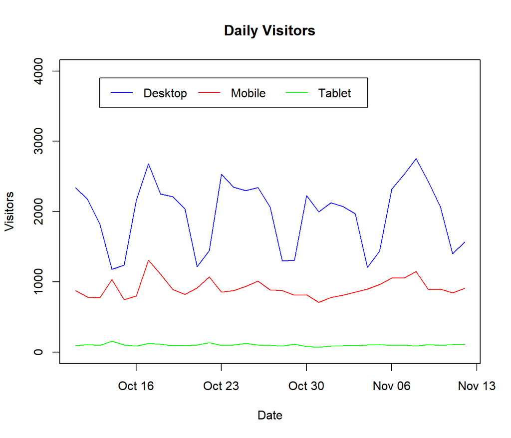

## Data

```r
users <- readr::read_csv('https://raw.githubusercontent.com/rsquaredacademy/datasets/master/users_device.csv',
  col_types = list(col_date(format = "%m/%d/%y"), col_integer(),
                   col_integer(), col_integer()))
```

```
## # A tibble: 33 x 4
##          Date Desktop Mobile Tablet
##        <date>   <int>  <int>  <int>
##  1 2017-10-11    2345    876     92
##  2 2017-10-12    2173    784    111
##  3 2017-10-13    1826    772     97
##  4 2017-10-14    1178   1032    155
##  5 2017-10-15    1239    747    105
##  6 2017-10-16    2158    801     85
##  7 2017-10-17    2682   1307    127
##  8 2017-10-18    2252   1110    112
##  9 2017-10-19    2210    891     93
## 10 2017-10-20    2040    824     94
## # ... with 23 more rows
```

## Data Dictionary

Below is the description of the data set:

- Date: date
- Desktop: visitors from a desktop device
- Mobile: visitors from a mobile device
- Tablet: visitors from a tablet device

## Line Graph

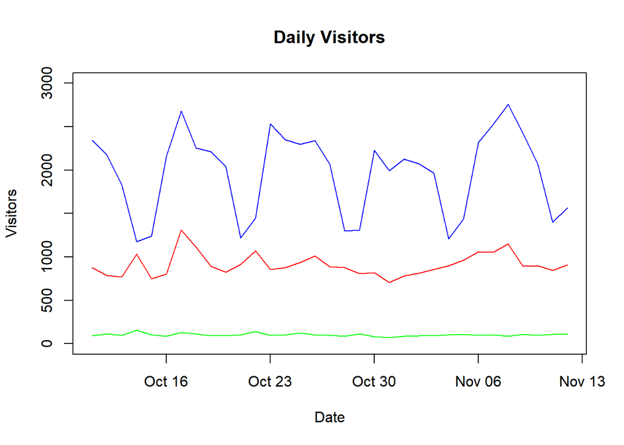

```r
plot(users$Date, users$Desktop, type = "l", col = "blue", main = 'Daily Visitors',
     ylim = c(0, 3000), xlab = 'Date', ylab = 'Visitors')
lines(users$Date, users$Mobile, type = "l", col = "red")
lines(users$Date, users$Tablet, type = "l", col = "green")
```

## Legend Location

- use x and y axis coordinates
- use keywords
  - top
  - bottom
  - left
  - right
  - center
  - bottomright
  - bottomleft
  - topright
  - topleft

## Legend Location

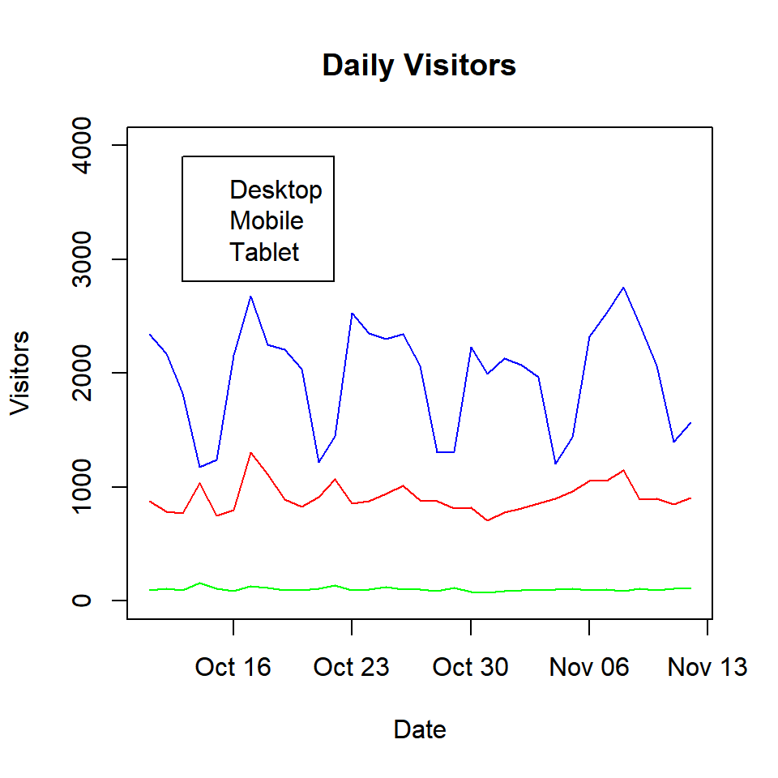

```r
{plot(users$Date, users$Desktop, type = "l", col = "blue", main = 'Daily Visitors',
     ylim = c(0, 4000), xlab = 'Date', ylab = 'Visitors')
lines(users$Date, users$Mobile, type = "l", col = "red")
lines(users$Date, users$Tablet, type = "l", col = "green")
legend(x = as.Date('2017-10-13'), y = 3900, legend = c('Desktop', 'Mobile', 'Tablet'))}
```

## Legend Location

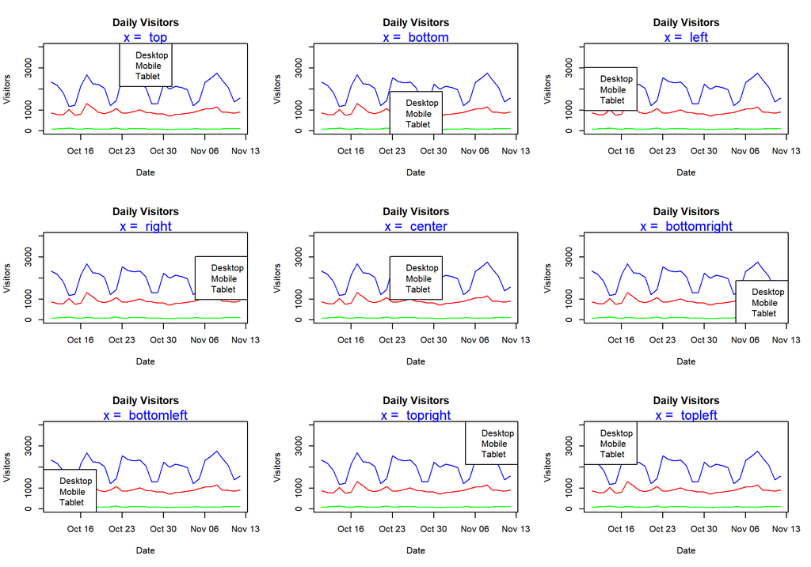

## Lines

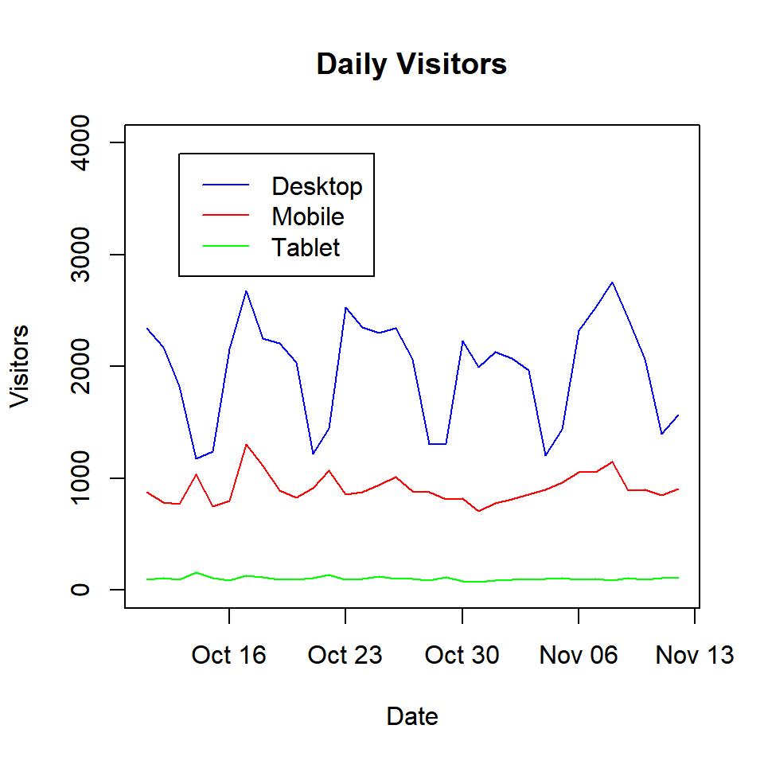

```r
{plot(users$Date, users$Desktop, type = "l", col = "blue", main = 'Daily Visitors',
     ylim = c(0, 4000), xlab = 'Date', ylab = 'Visitors')
lines(users$Date, users$Mobile, type = "l", col = "red")
lines(users$Date, users$Tablet, type = "l", col = "green")
legend(x = as.Date('2017-10-13'), y = 3900, legend = c('Desktop', 'Mobile', 'Tablet'), lty = 1,
       col = c('blue', 'red', 'green'))}
```

## Points

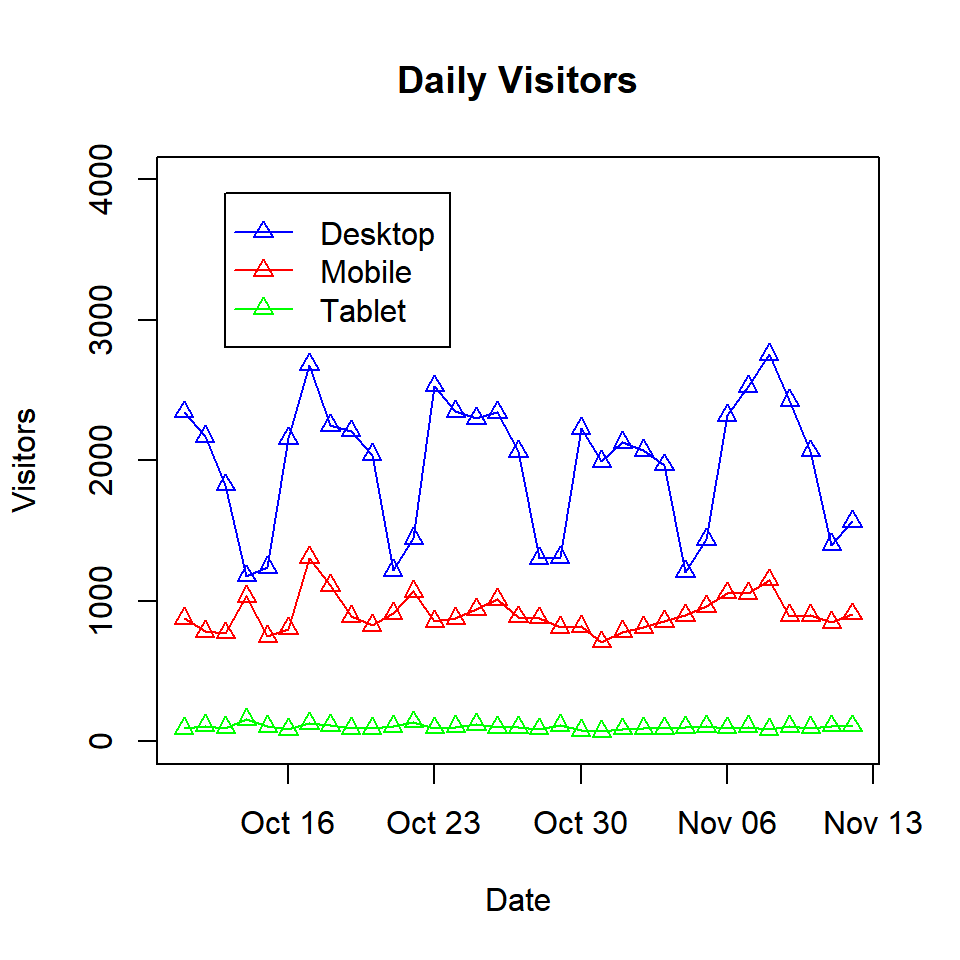

```r
{plot(users$Date, users$Desktop, type = "l", col = "blue", main = 'Daily Visitors',
     ylim = c(0, 4000), xlab = 'Date', ylab = 'Visitors')
points(users$Date, users$Desktop, pch = 2, col = 'blue')
lines(users$Date, users$Mobile, type = "l", col = "red")
points(users$Date, users$Mobile, pch = 2, col = 'red')
lines(users$Date, users$Tablet, type = "l", col = "green")
points(users$Date, users$Tablet, pch = 2, col = 'green')
legend(x = as.Date('2017-10-13'), y = 3900, legend = c('Desktop', 'Mobile', 'Tablet'), lty = 1,
       col = c('blue', 'red', 'green'), pch = 2)}
```

## Text Placement

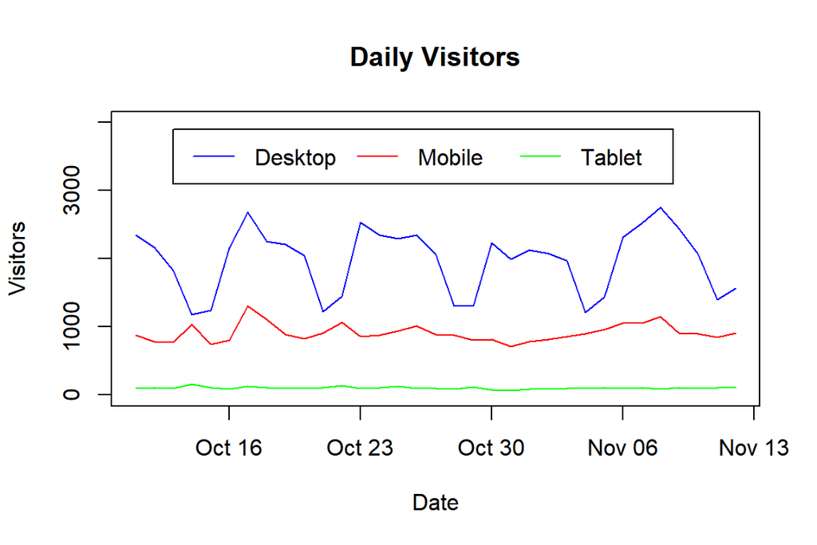

```r
{plot(users$Date, users$Desktop, type = "l", col = "blue", main = 'Daily Visitors',
     ylim = c(0, 4000), xlab = 'Date', ylab = 'Visitors')
lines(users$Date, users$Mobile, type = "l", col = "red")
lines(users$Date, users$Tablet, type = "l", col = "green")
legend(x = as.Date('2017-10-13'), y = 3900, legend = c('Desktop', 'Mobile', 'Tablet'), lty = 1,
       col = c('blue', 'red', 'green'), horiz = TRUE)}
```

## Text Placement

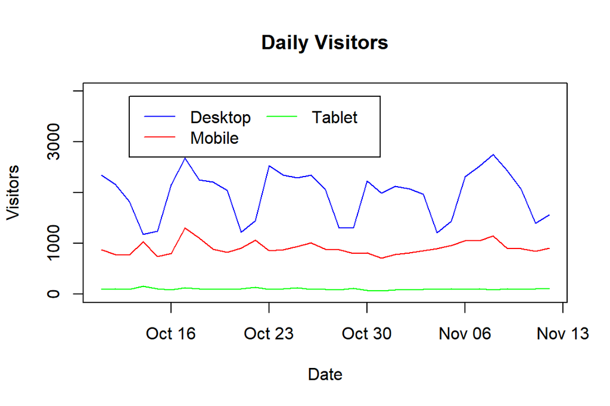

```r
{plot(users$Date, users$Desktop, type = "l", col = "blue", main = 'Daily Visitors',
     ylim = c(0, 4000), xlab = 'Date', ylab = 'Visitors')
lines(users$Date, users$Mobile, type = "l", col = "red")
lines(users$Date, users$Tablet, type = "l", col = "green")
legend(x = as.Date('2017-10-13'), y = 3900, legend = c('Desktop', 'Mobile', 'Tablet'), lty = 1,
       col = c('blue', 'red', 'green'), ncol = 2)}
```

## Text Placement

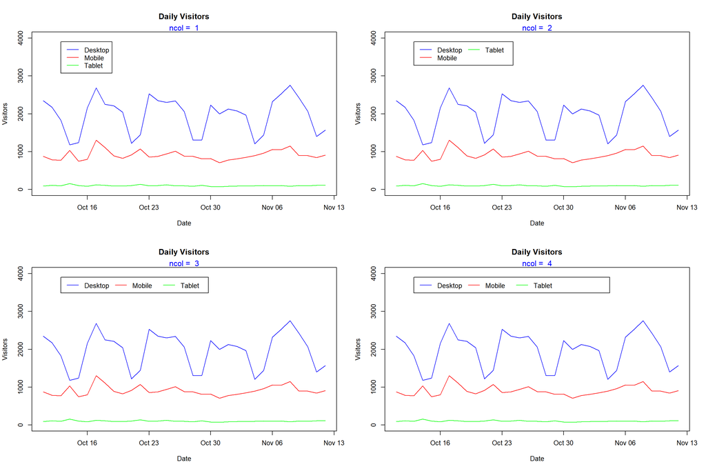

## Title

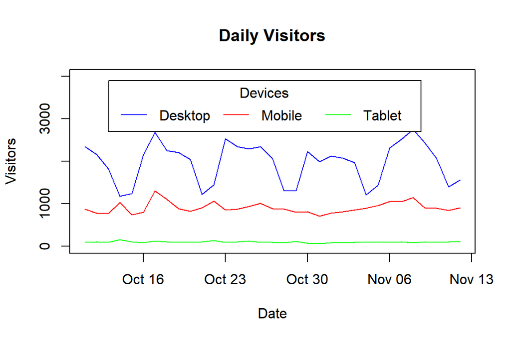

```r
{plot(users$Date, users$Desktop, type = "l", col = "blue", main = 'Daily Visitors',
     ylim = c(0, 4000), xlab = 'Date', ylab = 'Visitors')
lines(users$Date, users$Mobile, type = "l", col = "red")
lines(users$Date, users$Tablet, type = "l", col = "green")
legend(x = as.Date('2017-10-13'), y = 3900, legend = c('Desktop', 'Mobile', 'Tablet'), lty = 1,
       col = c('blue', 'red', 'green'), title = 'Devices', horiz = TRUE)}
```

## Title Color

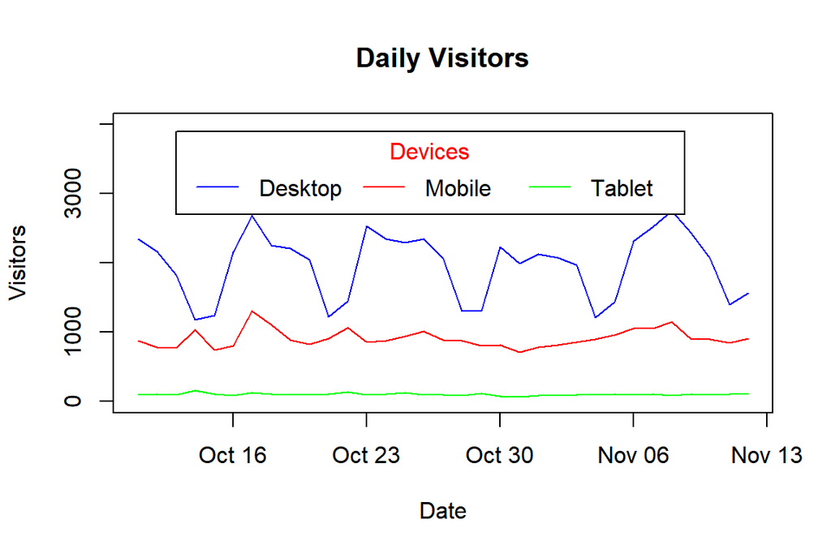

```r
{plot(users$Date, users$Desktop, type = "l", col = "blue", main = 'Daily Visitors',
     ylim = c(0, 4000), xlab = 'Date', ylab = 'Visitors')
lines(users$Date, users$Mobile, type = "l", col = "red")
lines(users$Date, users$Tablet, type = "l", col = "green")
legend(x = as.Date('2017-10-13'), y = 3900, legend = c('Desktop', 'Mobile', 'Tablet'), lty = 1,
       col = c('blue', 'red', 'green'), title = 'Devices', title.col = 'red', horiz = TRUE)}
```

## Title Position

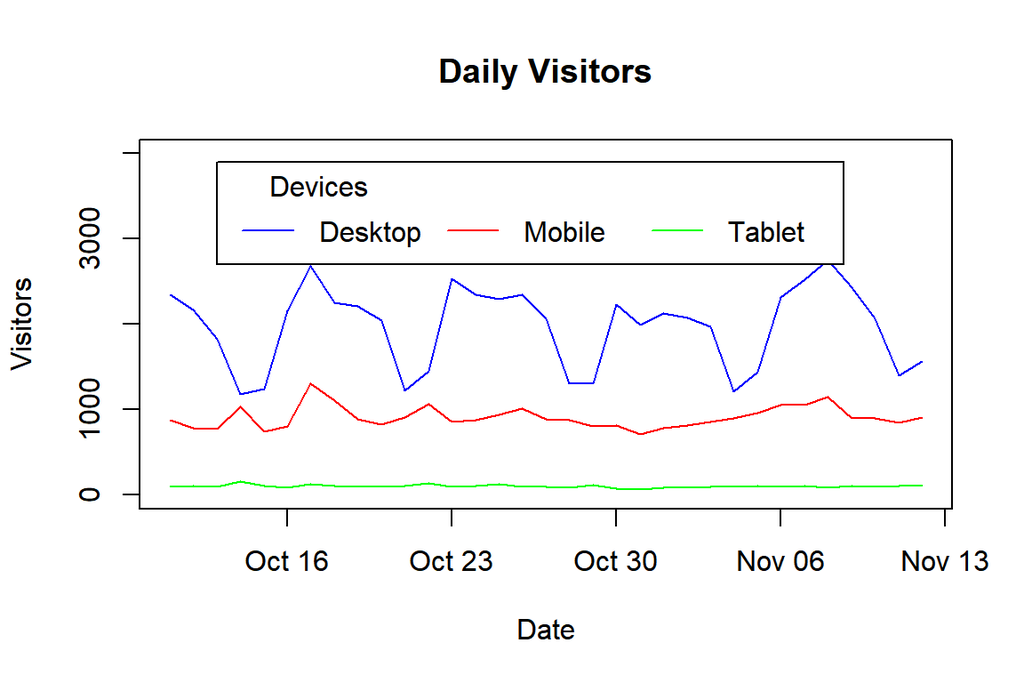

```r
{plot(users$Date, users$Desktop, type = "l", col = "blue", main = 'Daily Visitors',
     ylim = c(0, 4000), xlab = 'Date', ylab = 'Visitors')
lines(users$Date, users$Mobile, type = "l", col = "red")
lines(users$Date, users$Tablet, type = "l", col = "green")
legend(x = as.Date('2017-10-13'), y = 3900, legend = c('Desktop', 'Mobile', 'Tablet'), lty = 1,
       col = c('blue', 'red', 'green'), title = 'Devices', title.adj = 0.1, horiz = TRUE)}
```

## Title Position

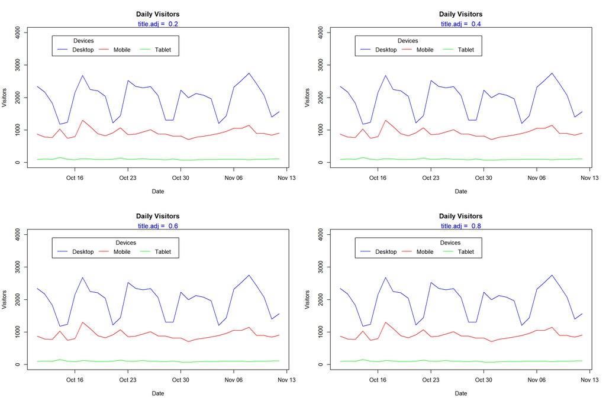

## Box Appearance

| option | argument | values |
| --- | --- | --- |
| Box Type | bty | o, n |
| Background Color | bg | blue, #0000ff |
| Border Line Type | box.lty | 1:5 |
| Border Line Width | box.lwd | 0.5, 1, 1.5 |
| Border Line Color | box.col | blue, #0000ff |
| Horizontal Justification | xjust | 0:1 |
| Vertical Justification | yjust | 0:1 |
| Text Color | text.col | blue, #0000ff |
| Text Font | text.font | 1:5 |

## Box Type

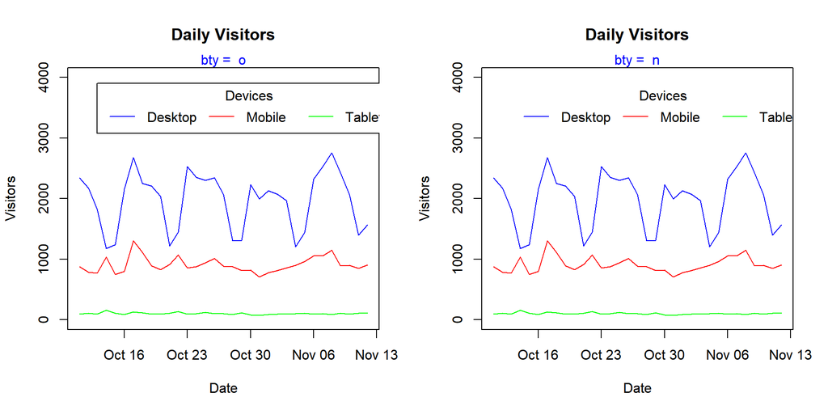

## Background Color

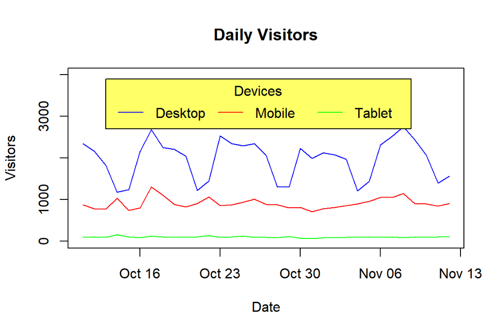

```r
{plot(users$Date, users$Desktop, type = "l", col = "blue", main = 'Daily Visitors',
     ylim = c(0, 4000), xlab = 'Date', ylab = 'Visitors')
lines(users$Date, users$Mobile, type = "l", col = "red")
lines(users$Date, users$Tablet, type = "l", col = "green")
legend(x = as.Date('2017-10-13'), y = 3900, legend = c('Desktop', 'Mobile', 'Tablet'), lty = 1,
       col = c('blue', 'red', 'green'), title = 'Devices', bg = '#ffff66', horiz = TRUE)}
```

## Border

The following arguments can be used to modify the border of the legend box:

- `box.lty`: line type
- `box.lwd`: line width
- `box.col`: color

## Border

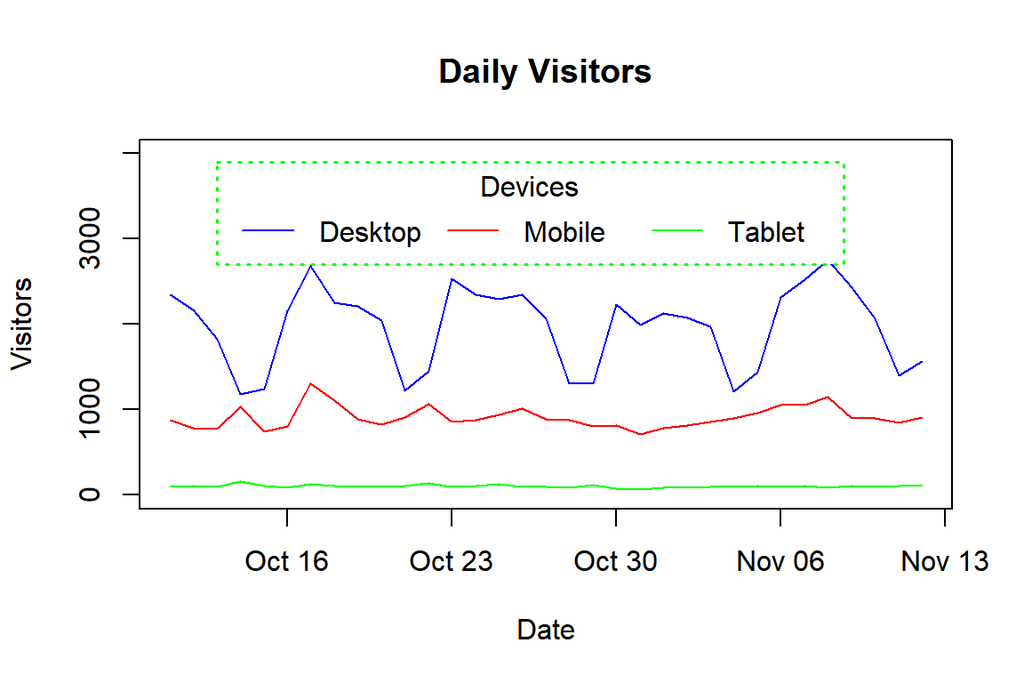

```r
{plot(users$Date, users$Desktop, type = "l", col = "blue", main = 'Daily Visitors',
     ylim = c(0, 4000), xlab = 'Date', ylab = 'Visitors')
lines(users$Date, users$Mobile, type = "l", col = "red")
lines(users$Date, users$Tablet, type = "l", col = "green")
legend(x = as.Date('2017-10-13'), y = 3900, legend = c('Desktop', 'Mobile', 'Tablet'), lty = 1,
       col = c('blue', 'red', 'green'), title = 'Devices', horiz = TRUE,
       box.lty = 3, box.lwd = 1.5, box.col = 'green')}
```

## Justification

The `xjust` and `yjust` arguments can be used to position the legend relative to the **X** and **Y** axis respectively. Listed below is the value and the respective justification:

- `0`: left justified
- `0.5`: centered
- `1`: right justified

## Horizontal Justification

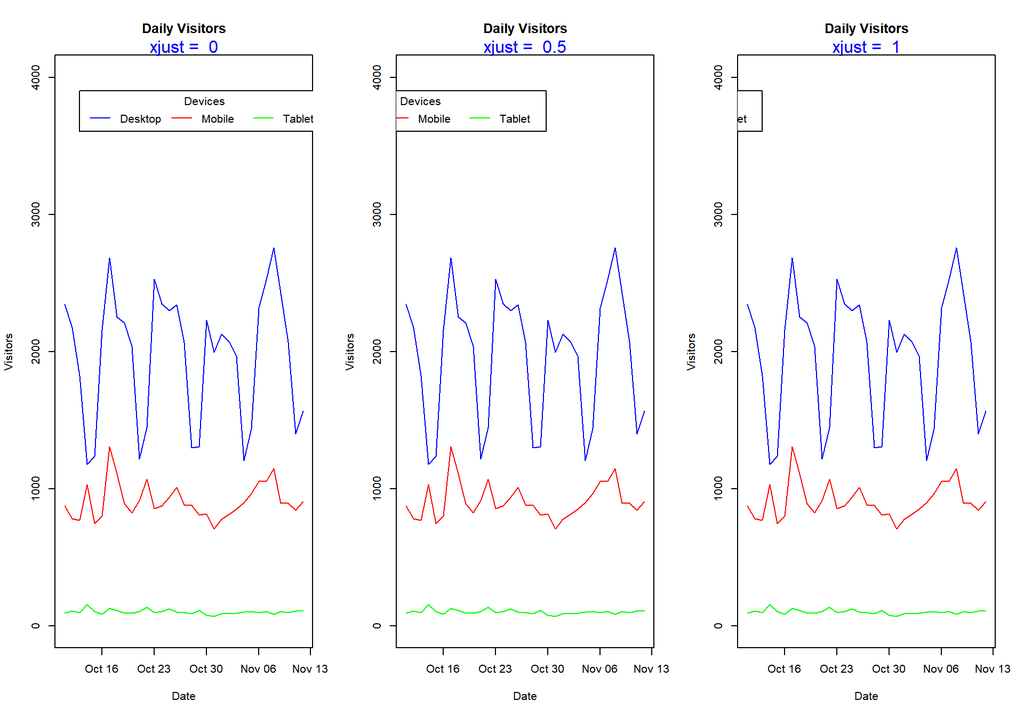

## Vertical Justification

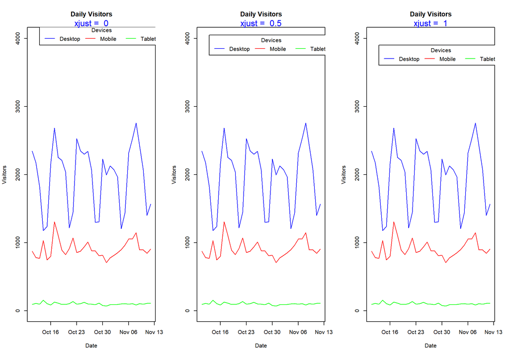

## Text Appearance

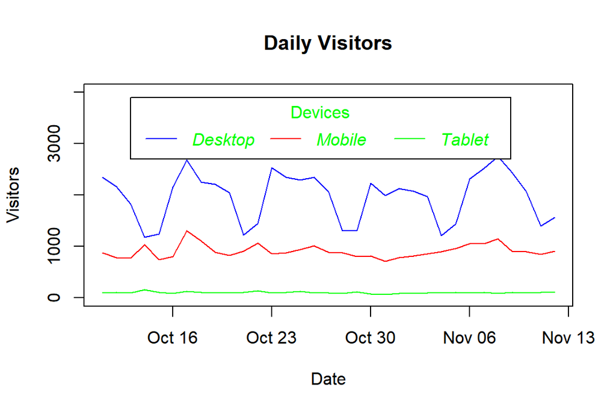

```r
{plot(users$Date, users$Desktop, type = "l", col = "blue", main = 'Daily Visitors',
     ylim = c(0, 4000), xlab = 'Date', ylab = 'Visitors')
lines(users$Date, users$Mobile, type = "l", col = "red")
lines(users$Date, users$Tablet, type = "l", col = "green")
legend(x = as.Date('2017-10-13'), y = 3900, legend = c('Desktop', 'Mobile', 'Tablet'), lty = 1,
       col = c('blue', 'red', 'green'), title = 'Devices',
       text.col = 'green', text.font = 3, horiz = TRUE)}
```